# Rookery Bay Aquatic Preserve

SEACAR Water Quality Analysis

Last compiled on 15 July, 2026

# Indicators

## Nutrients

### Total Nitrogen - Discrete

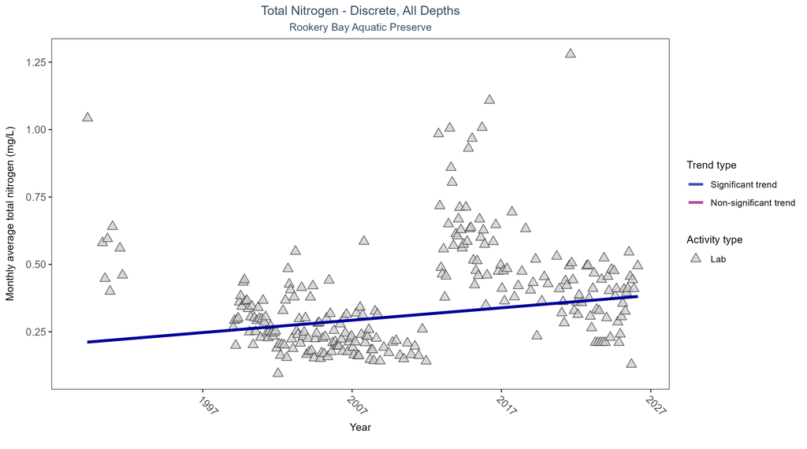

Scatter plot of monthly average total nitrogen over time. If the time series included ten or more years of discrete observations, a significant (blue) or non-significant (magenta) trend line is also shown. Only nitrogen values obtained from laboratory analyses (triangles) are included in the plot.

Table:

Monthly average total nitrogen increased by less than 0.01 mg/L per year.

| Activity Type | Statistical Trend | Sample Count | Years with Data | Period of Record | Median Result Value | Tau | Sen Intercept | Sen Slope | P |
| --- | --- | --- | --- | --- | --- | --- | --- | --- | --- |
| Lab | Increasing trend | 2653 | 31 | 1989 - 2026 | 0.26 | 0.16702 | 0.21032 | 0.00459 | 0.0003 |

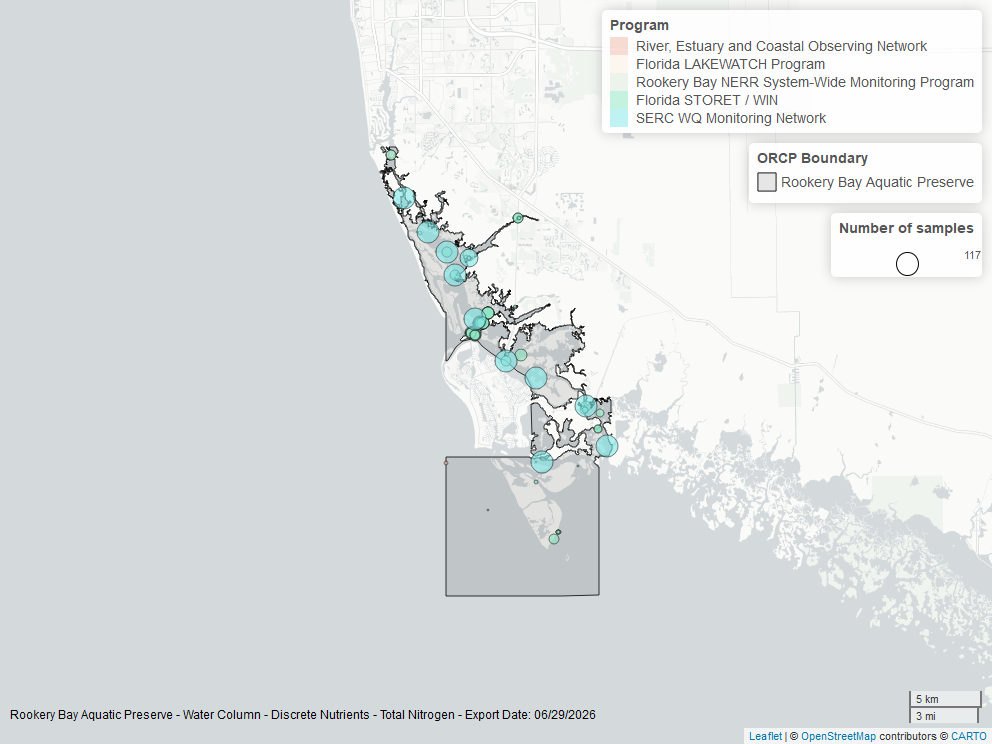

Map showing location of discrete water quality sampling locations within the boundaries of *Rookery Bay Aquatic Preserve*. The bubble size on the maps above reflect the amount of data available at each sampling site.

### Total Phosphorus - Discrete

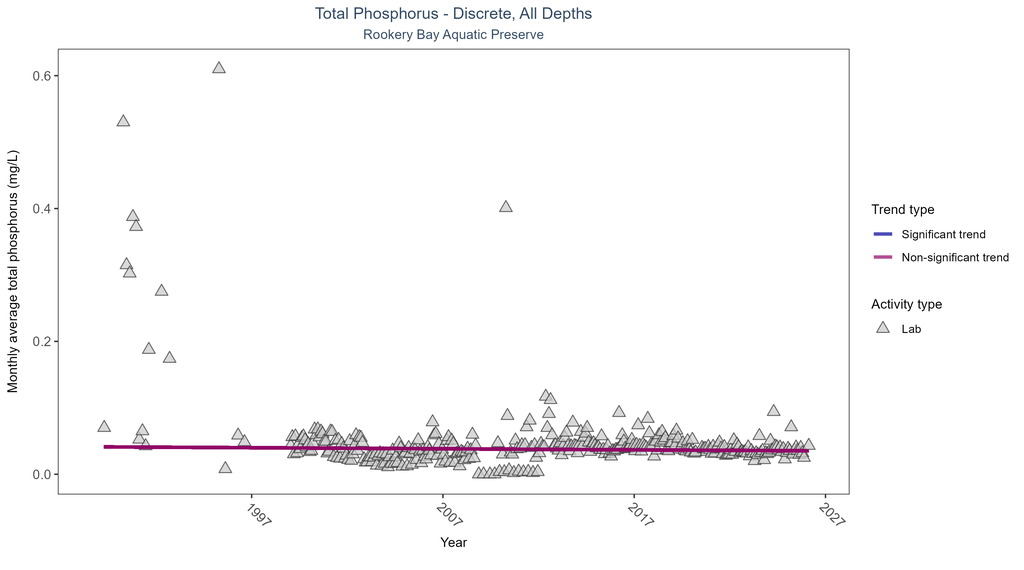

Scatter plot of monthly average total phosphorus over time. If the time series included ten or more years of discrete observations, a significant (blue) or non-significant (magenta) trend line is also shown. Only phosphorus values obtained from laboratory analyses (triangles) are included in the plot.

Table:

Total phosphorus showed no detectable trend between 1989 and 2026.

| Activity Type | Statistical Trend | Sample Count | Years with Data | Period of Record | Median Result Value | Tau | Sen Intercept | Sen Slope | P |
| --- | --- | --- | --- | --- | --- | --- | --- | --- | --- |
| Lab | No detectable trend | 2287 | 34 | 1989 - 2026 | 0.034 | -0.04792 | 0.04121 | -0.00016 | 0.1787 |

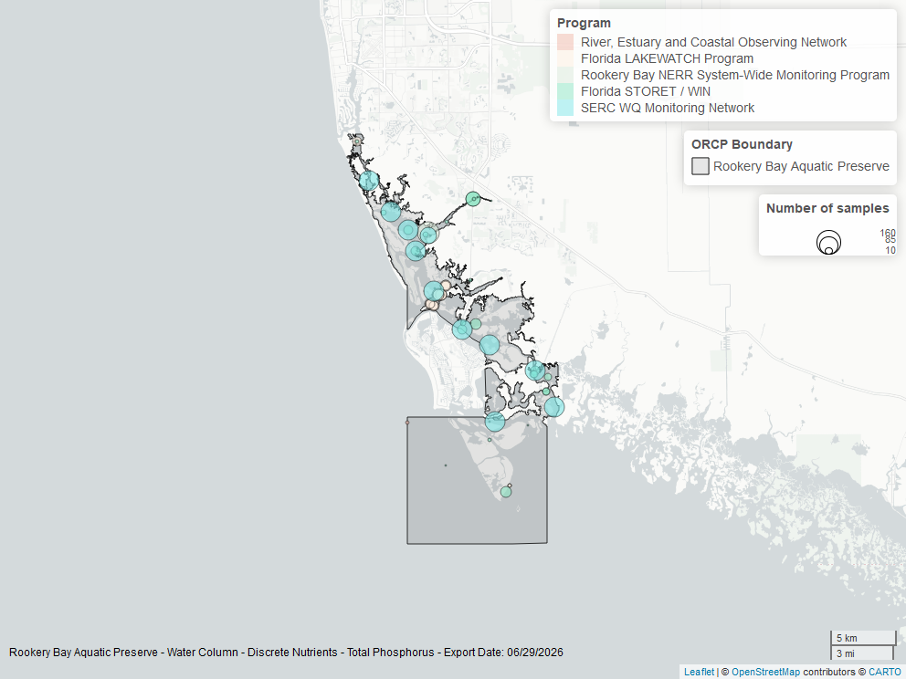

Map showing location of discrete water quality sampling locations within the boundaries of *Rookery Bay Aquatic Preserve*. The bubble size on the maps above reflect the amount of data available at each sampling site.

## Water Quality

### Dissolved Oxygen - Continuous

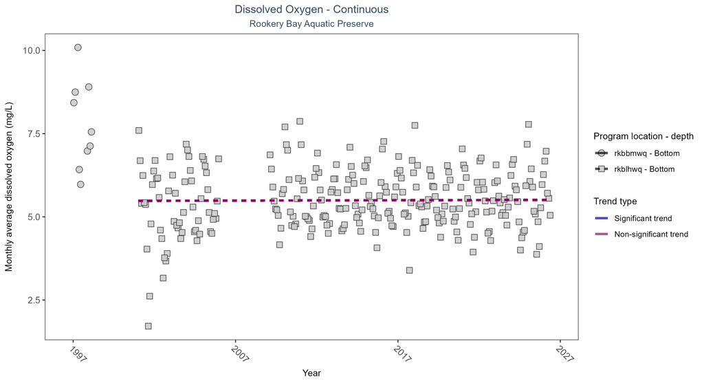

Scatter plot of monthly average dissolved oxygen over time at continuously monitored program locations. Each location is analyzed separately, with significant (blue) or non-significant (magenta) trend lines shown for time series that included five or more years of observations.

Table:

No detectable change in monthly average dissolved oxygen was observed at one location. There was insufficient data to fit a model for one location.

| Program Location | Statistical Trend | Sample Count | Years with Data | Period of Record | Median Result Value | Tau | Sen Intercept | Sen Slope | P |
| --- | --- | --- | --- | --- | --- | --- | --- | --- | --- |
| rkbbmwq | Insufficient data | 10441 | 2 | 1997 - 1998 | 7.2 | - | - | - | - |
| rkblhwq | No detectable trend | 622816 | 23 | 2001 - 2026 | 5.6 | 0.01 | 5.48 | 0 | 0.74 |

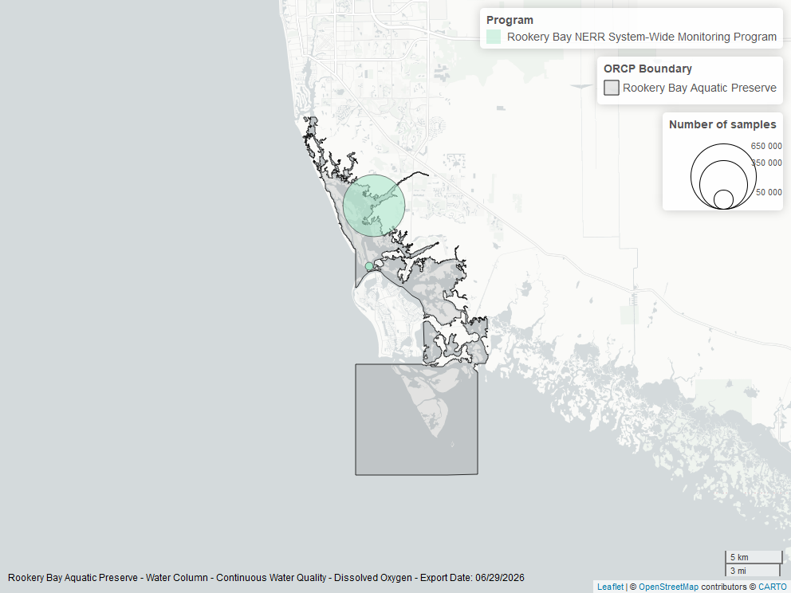

Map showing location of dissolved oxygen continuous water quality sampling locations within the boundaries of *Rookery Bay Aquatic Preserve*. The bubble size on the maps above reflect the amount of data available at each sampling site.

### Dissolved Oxygen - Discrete

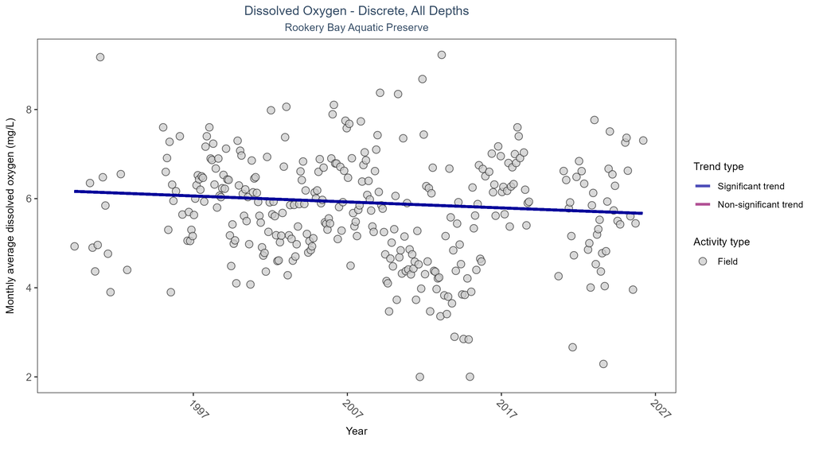

Scatter plot of monthly average dissolved oxygen over time. If the time series included ten or more years of discrete observations, a significant (blue) or non-significant (magenta) trend line is also shown. Only dissolved oxygen values measured in the field (circles) are included in the plot.

Table:

Monthly average dissolved oxygen decreased by 0.01 mg/L per year.

| Activity Type | Statistical Trend | Sample Count | Years with Data | Period of Record | Median Result Value | Tau | Sen Intercept | Sen Slope | P |
| --- | --- | --- | --- | --- | --- | --- | --- | --- | --- |
| Field | Decreasing trend | 3926 | 35 | 1989 - 2026 | 5.9 | -0.08699 | 6.16708 | -0.01339 | 0.0304 |

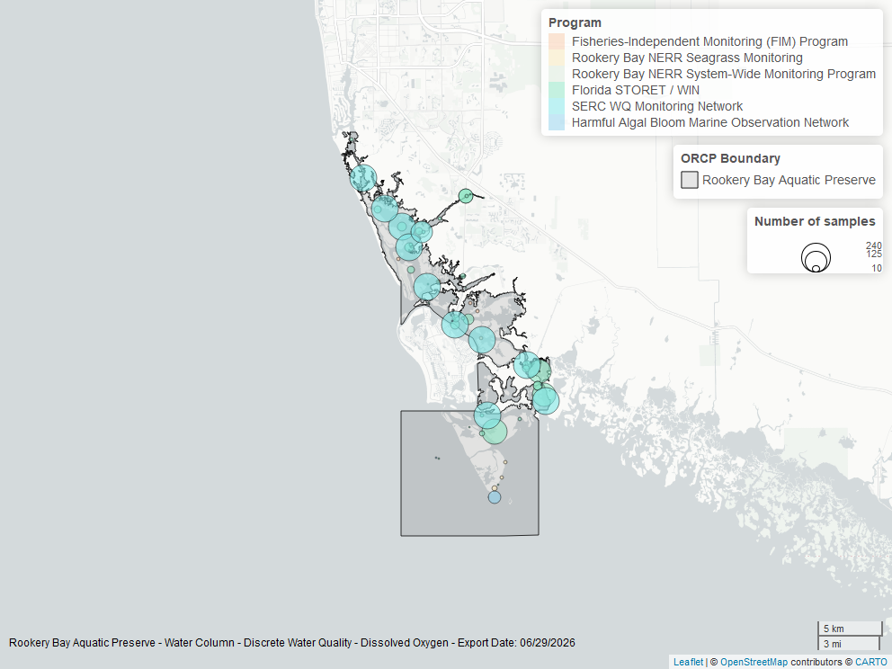

Map showing location of discrete water quality sampling locations within the boundaries of *Rookery Bay Aquatic Preserve*. The bubble size on the maps above reflect the amount of data available at each sampling site.

### Dissolved Oxygen Saturation - Continuous

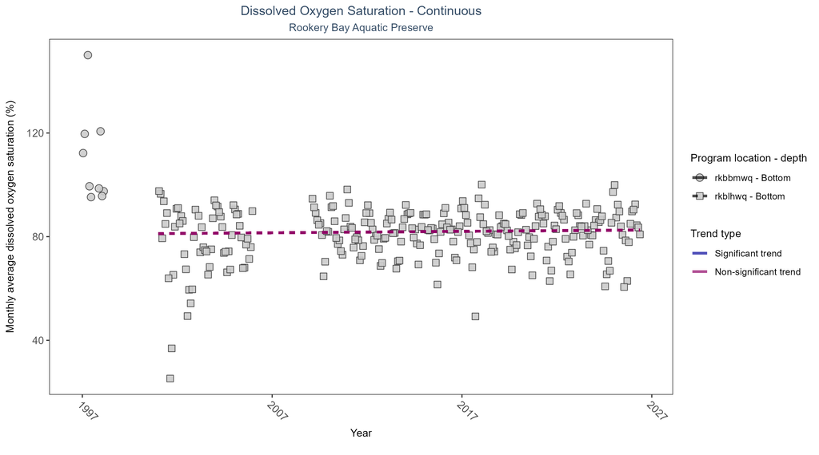

Scatter plot of monthly average dissolved oxygen saturation over time at continuously monitored program locations. Each location is analyzed separately, with significant (blue) or non-significant (magenta) trend lines shown for time series that included five or more years of observations.

Table:

No detectable change in monthly average dissolved oxygen saturation was observed at one location. There was insufficient data to fit a model for one location.

| Program Location | Statistical Trend | Sample Count | Years with Data | Period of Record | Median Result Value | Tau | Sen Intercept | Sen Slope | P |
| --- | --- | --- | --- | --- | --- | --- | --- | --- | --- |
| rkbbmwq | Insufficient data | 10441 | 2 | 1997 - 1998 | 102.4 | - | - | - | - |
| rkblhwq | No detectable trend | 635134 | 23 | 2001 - 2026 | 82.1 | 0.05 | 81.17 | 0.05 | 0.22 |

[figure not shown]

Map showing location of dissolved oxygen saturation continuous water quality sampling locations within the boundaries of *Rookery Bay Aquatic Preserve*. The bubble size on the maps above reflect the amount of data available at each sampling site.

### Dissolved Oxygen Saturation - Discrete

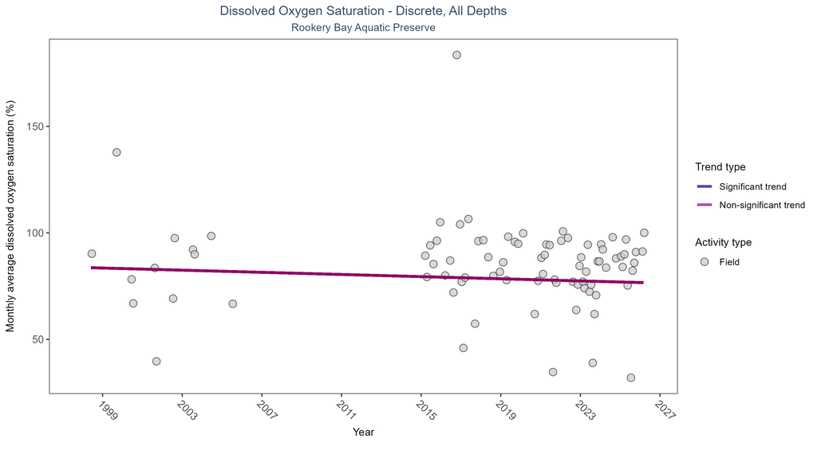

Scatter plot of monthly average dissolved oxygen saturation over time. If the time series included ten or more years of discrete observations, a significant (blue) or non-significant (magenta) trend line is also shown. Only dissolved oxygen saturation values measured in the field (circles) are included in the plot.

Table:

Dissolved oxygen saturation showed no detectable trend between 1998 and 2026.

| Activity Type | Statistical Trend | Sample Count | Years with Data | Period of Record | Median Result Value | Tau | Sen Intercept | Sen Slope | P |
| --- | --- | --- | --- | --- | --- | --- | --- | --- | --- |
| Field | No detectable trend | 208 | 20 | 1998 - 2026 | 86.85 | -0.05272 | 83.74348 | -0.25217 | 0.6339 |

[figure not shown]

Map showing location of discrete water quality sampling locations within the boundaries of *Rookery Bay Aquatic Preserve*. The bubble size on the maps above reflect the amount of data available at each sampling site.

### Salinity - Discrete

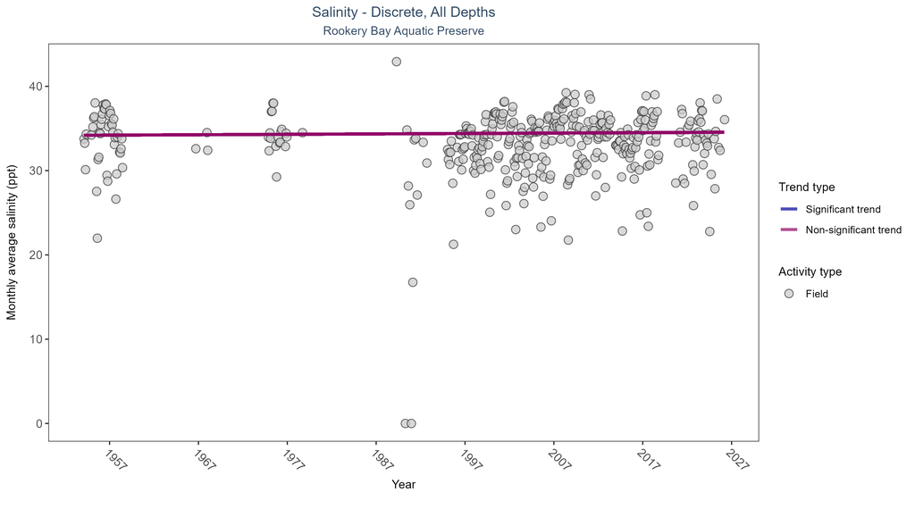

Table:

Salinity showed no detectable trend between 1954 and 2026.

| Activity Type | Statistical Trend | Sample Count | Years with Data | Period of Record | Median Result Value | Tau | Sen Intercept | Sen Slope | P |
| --- | --- | --- | --- | --- | --- | --- | --- | --- | --- |
| All | No detectable trend | 4657 | 47 | 1954 - 2026 | 34.24 | 0.02638 | 34.19068 | 0.00494 | 0.4739 |

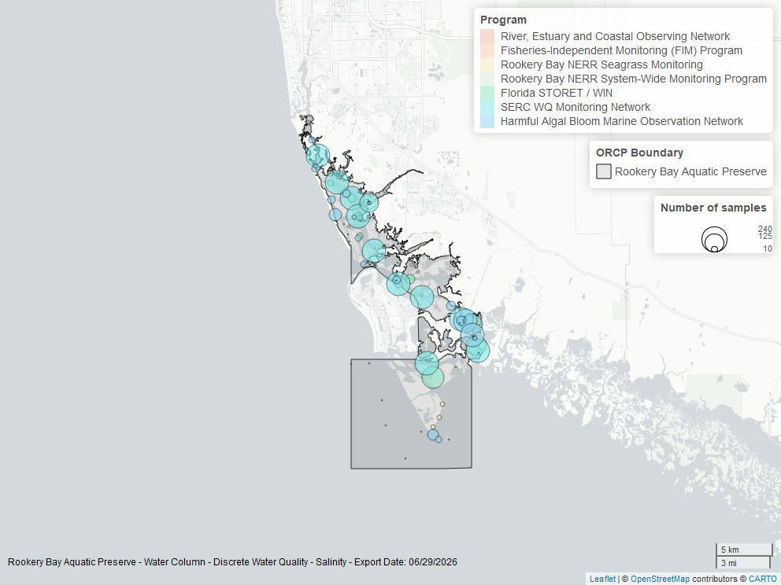

Map showing location of discrete water quality sampling locations within the boundaries of *Rookery Bay Aquatic Preserve*. The bubble size on the maps above reflect the amount of data available at each sampling site.

### Salinity - Continuous

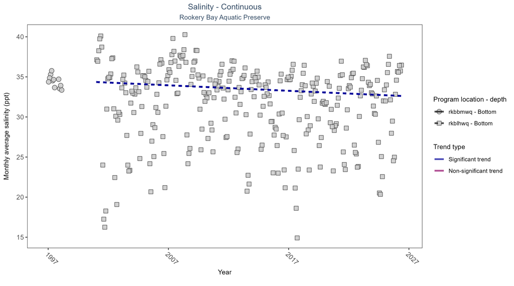

Scatter plot of monthly average salinity over time at continuously monitored program locations. Each location is analyzed separately, with significant (blue) or non-significant (magenta) trend lines shown for time series that included five or more years of observations.

Table:

At one program location, monthly average salinity decreased by 0.07 ppt per year. There was insufficient data to fit a model for one location.

| Program Location | Statistical Trend | Sample Count | Years with Data | Period of Record | Median Result Value | Tau | Sen Intercept | Sen Slope | P |
| --- | --- | --- | --- | --- | --- | --- | --- | --- | --- |
| rkbbmwq | Insufficient data | 12256 | 2 | 1997 - 1998 | 34.5 | - | - | - | - |
| rkblhwq | Decreasing trend | 709967 | 26 | 2001 - 2026 | 33.2 | -0.12 | 34.36 | -0.07 | 0 |

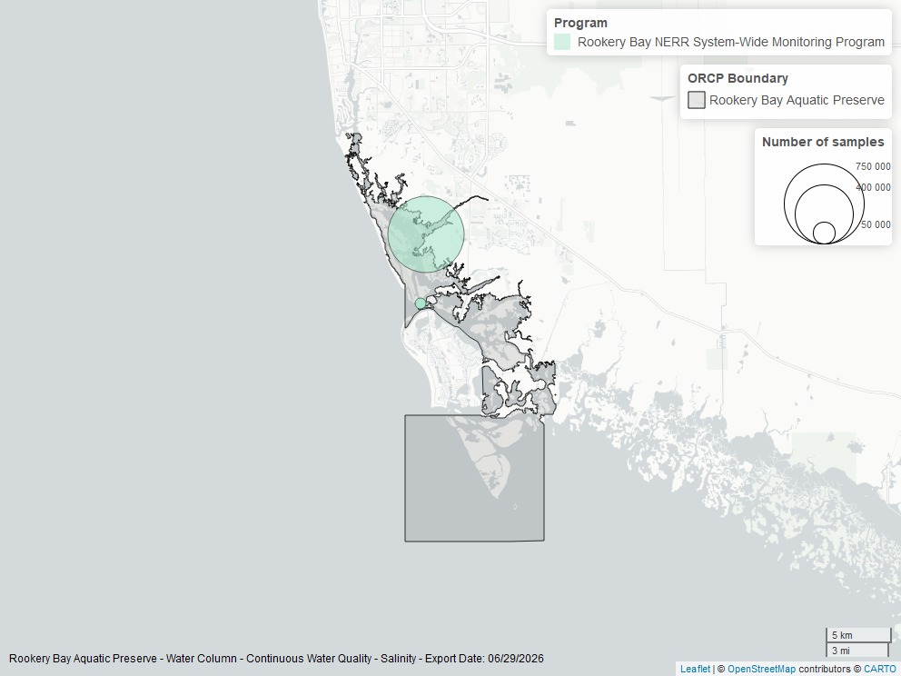

Map showing location of salinity continuous water quality sampling locations within the boundaries of *Rookery Bay Aquatic Preserve*. The bubble size on the maps above reflect the amount of data available at each sampling site.

### Water Temperature - Continuous

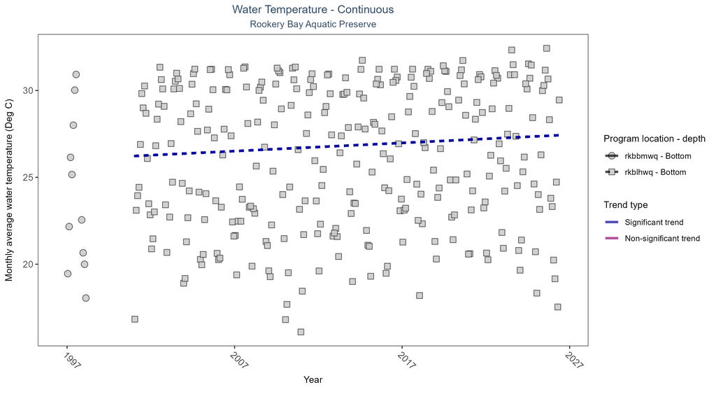

Scatter plot of monthly average water temperature over time at continuously monitored program locations. Each location is analyzed separately, with significant (blue) or non-significant (magenta) trend lines shown for time series that included five or more years of observations.

Table:

At one program location, monthly average water temperature increased by 0.05°C per year. There was insufficient data to fit a model for one location.

| Program Location | Statistical Trend | Sample Count | Years with Data | Period of Record | Median Result Value | Tau | Sen Intercept | Sen Slope | P |
| --- | --- | --- | --- | --- | --- | --- | --- | --- | --- |
| rkbbmwq | Insufficient data | 12610 | 2 | 1997 - 1998 | 23.8 | - | - | - | - |
| rkblhwq | Increasing trend | 741119 | 26 | 2001 - 2026 | 26.8 | 0.23 | 26.23 | 0.05 | 0 |

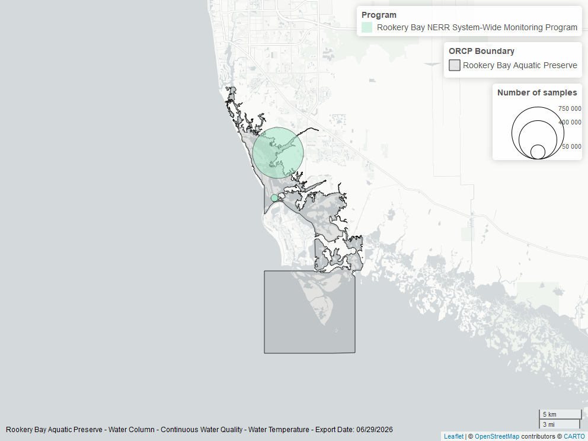

Map showing location of water temperature continuous water quality sampling locations within the boundaries of *Rookery Bay Aquatic Preserve*. The bubble size on the maps above reflect the amount of data available at each sampling site.

### Water Temperature - Discrete

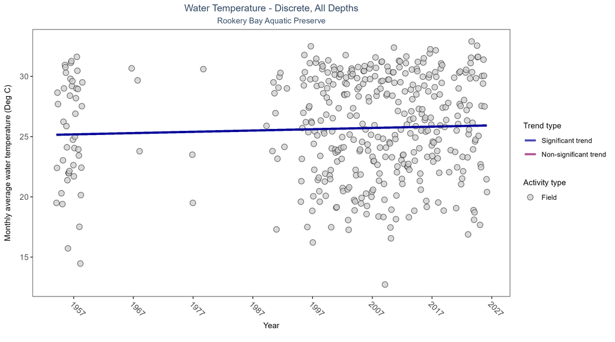

Scatter plot of monthly average water temperature over time. If the time series included ten or more years of discrete observations, a significant (blue) or non-significant (magenta) trend line is also shown. Only water temperature measurements taken in the field (circles) are included in the plot.

Table:

Monthly average water temperature increased by 0.01°C per year.

| Activity Type | Statistical Trend | Sample Count | Years with Data | Period of Record | Median Result Value | Tau | Sen Intercept | Sen Slope | P |
| --- | --- | --- | --- | --- | --- | --- | --- | --- | --- |
| Field | Increasing trend | 4592 | 46 | 1954 - 2026 | 26.2 | 0.08211 | 25.15326 | 0.01069 | 0.0148 |

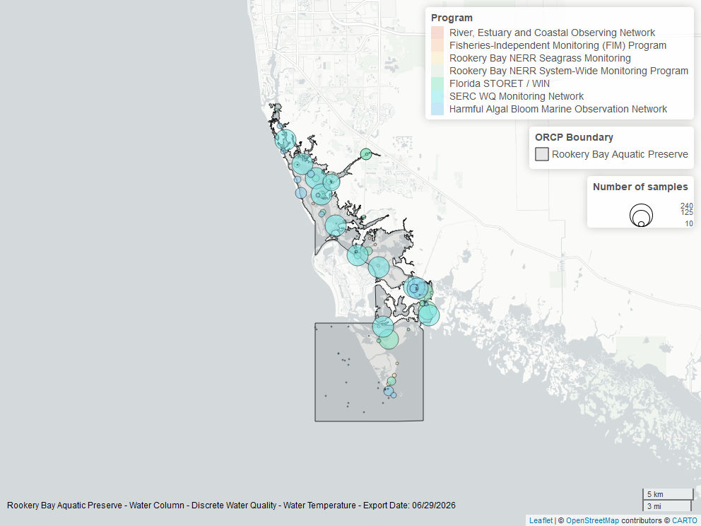

Map showing location of discrete water quality sampling locations within the boundaries of *Rookery Bay Aquatic Preserve*. The bubble size on the maps above reflect the amount of data available at each sampling site.

### pH - Continuous

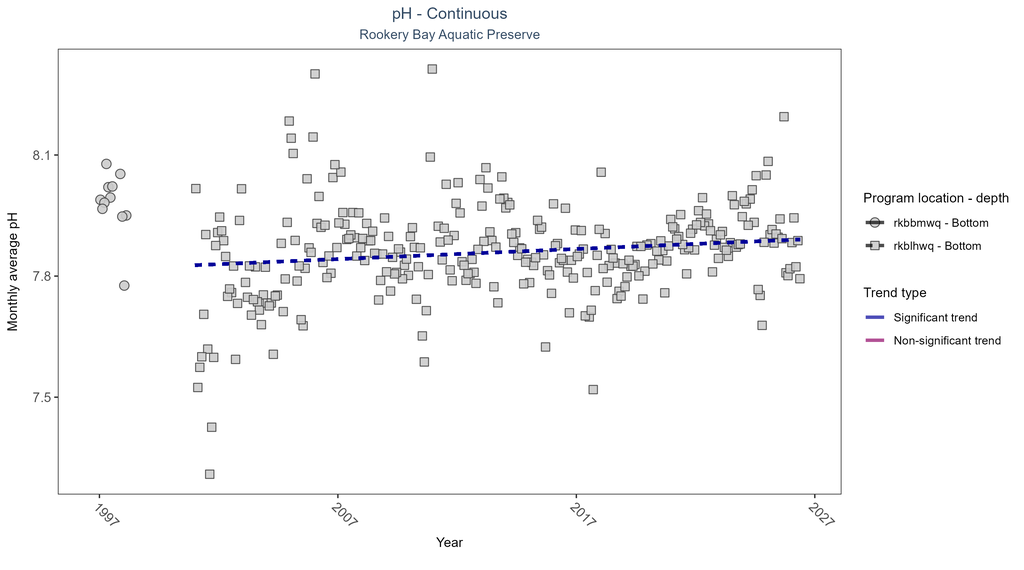

Scatter plot of monthly average pH over time at continuously monitored program locations. Each location is analyzed separately, with significant (blue) or non-significant (magenta) trend lines shown for time series that included five or more years of observations.

Table:

At one program location, monthly average pH increased by less than 0.01 pH units per year. There was insufficient data to fit a model for one location.

| Program Location | Statistical Trend | Sample Count | Years with Data | Period of Record | Median Result Value | Tau | Sen Intercept | Sen Slope | P |
| --- | --- | --- | --- | --- | --- | --- | --- | --- | --- |
| rkbbmwq | Insufficient data | 12610 | 2 | 1997 - 1998 | 8.0 | - | - | - | - |
| rkblhwq | Increasing trend | 680804 | 26 | 2001 - 2026 | 7.9 | 0.14 | 7.83 | 0 | 0 |

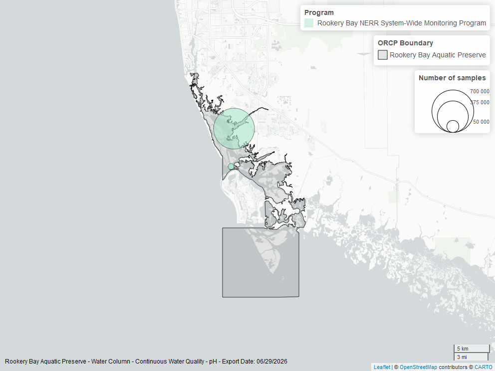

Map showing location of ph continuous water quality sampling locations within the boundaries of *Rookery Bay Aquatic Preserve*. The bubble size on the maps above reflect the amount of data available at each sampling site.

### pH - Discrete

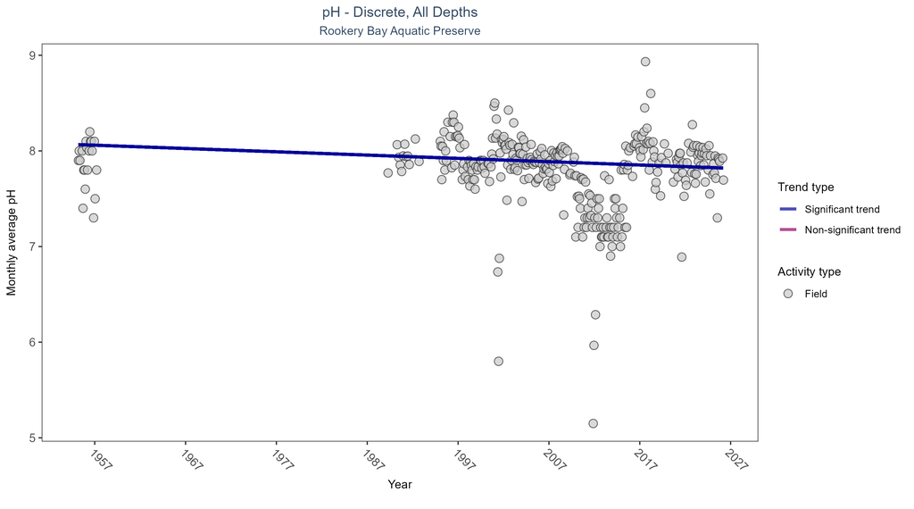

Scatter plot of monthly average pH over time. If the time series included ten or more years of discrete observations, a significant (blue) or non-significant (magenta) trend line is also shown. Only pH values measured in the field (circles) are included in the plot.

Table:

Monthly average pH decreased by less than 0.01 pH units per year.

| Activity Type | Statistical Trend | Sample Count | Years with Data | Period of Record | Median Result Value | Tau | Sen Intercept | Sen Slope | P |
| --- | --- | --- | --- | --- | --- | --- | --- | --- | --- |
| Field | Decreasing trend | 1898 | 39 | 1955 - 2026 | 7.9 | -0.13807 | 8.06668 | -0.00345 | 0.0003 |

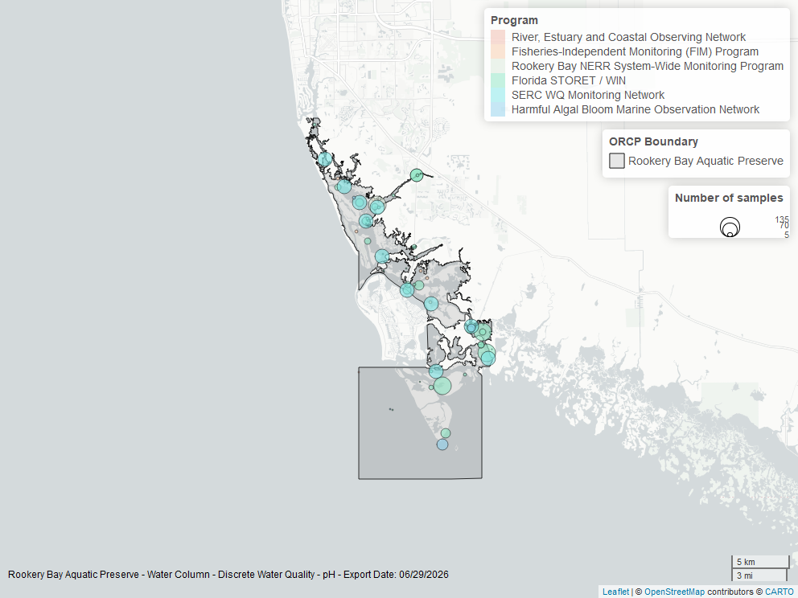

Map showing location of discrete water quality sampling locations within the boundaries of *Rookery Bay Aquatic Preserve*. The bubble size on the maps above reflect the amount of data available at each sampling site.

### Specific Conductivity - Continuous

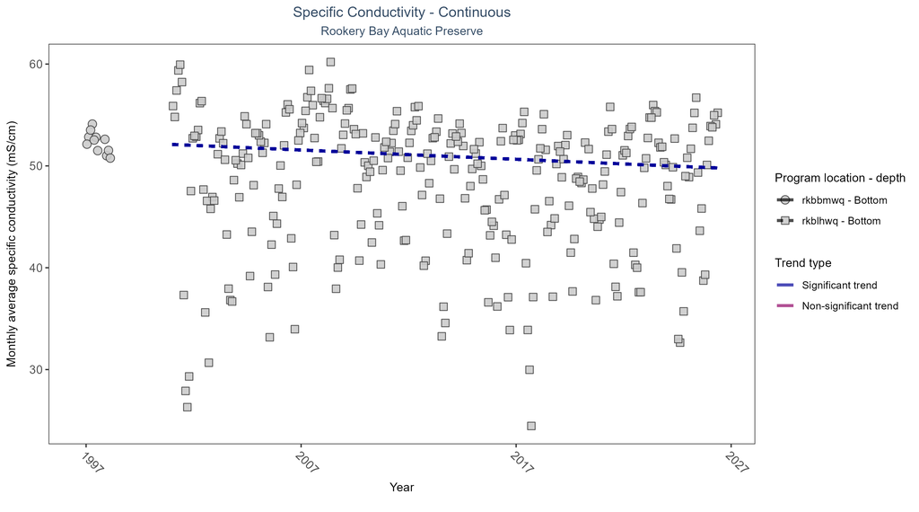

Scatter plot of monthly average specific conductivity over time at continuously monitored program locations. Each location is analyzed separately, with significant (blue) or non-significant (magenta) trend lines shown for time series that included five or more years of observations.

Table:

At one program location, monthly average specific conductivity decreased by 0.09 mS/cm per year. There was insufficient data to fit a model for one location.

| Program Location | Statistical Trend | Sample Count | Years with Data | Period of Record | Median Result Value | Tau | Sen Intercept | Sen Slope | P |
| --- | --- | --- | --- | --- | --- | --- | --- | --- | --- |
| rkbbmwq | Insufficient data | 12256 | 2 | 1997 - 1998 | 52.41 | - | - | - | - |
| rkblhwq | Decreasing trend | 710006 | 26 | 2001 - 2026 | 50.68 | -0.11 | 52.11 | -0.09 | 0.01 |

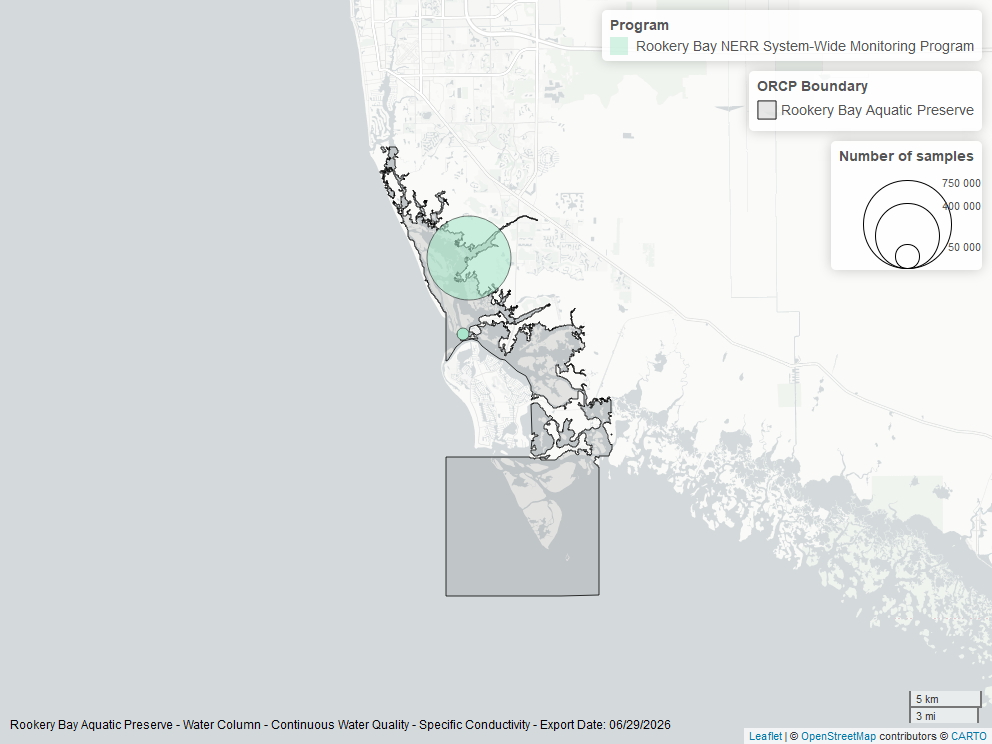

Map showing location of specific conductivity continuous water quality sampling locations within the boundaries of *Rookery Bay Aquatic Preserve*. The bubble size on the maps above reflect the amount of data available at each sampling site.

## Water Clarity

### Turbidity - Continuous

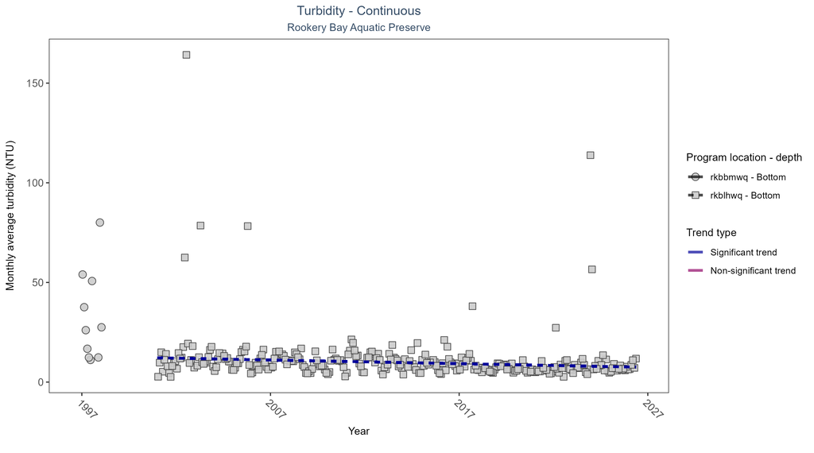

Scatter plot of monthly average turbidity over time at continuously monitored program locations. Each location is analyzed separately, with significant (blue) or non-significant (magenta) trend lines shown for time series that included five or more years of observations.

Table:

At one program location, monthly average turbidity decreased by 0.18 NTU per year. There was insufficient data to fit a model for one location.

| Program Location | Statistical Trend | Sample Count | Years with Data | Period of Record | Median Result Value | Tau | Sen Intercept | Sen Slope | P |
| --- | --- | --- | --- | --- | --- | --- | --- | --- | --- |
| rkbbmwq | Insufficient data | 10654 | 2 | 1997 - 1998 | 11 | - | - | - | - |
| rkblhwq | Decreasing trend | 657127 | 26 | 2001 - 2026 | 8 | -0.27 | 12.18 | -0.18 | 0 |

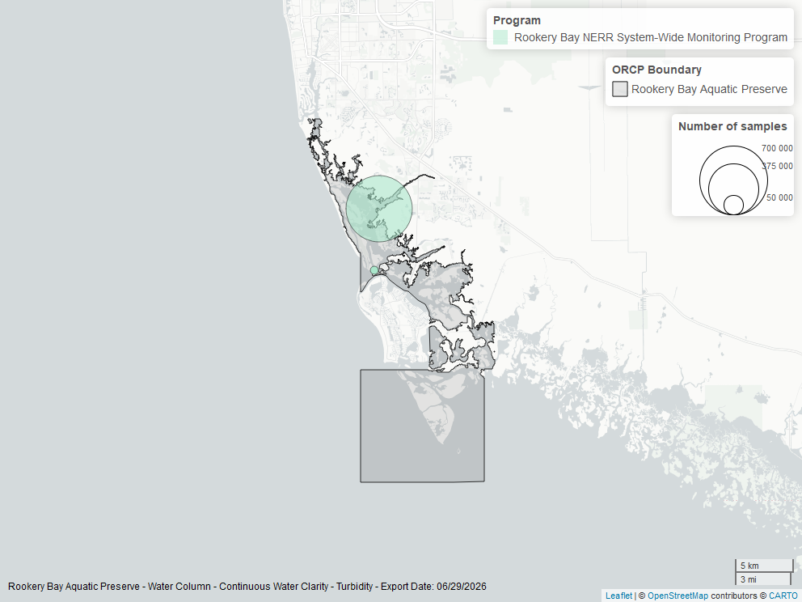

Map showing location of turbidity continuous water quality sampling locations within the boundaries of *Rookery Bay Aquatic Preserve*. The bubble size on the maps above reflect the amount of data available at each sampling site.

### Turbidity - Discrete

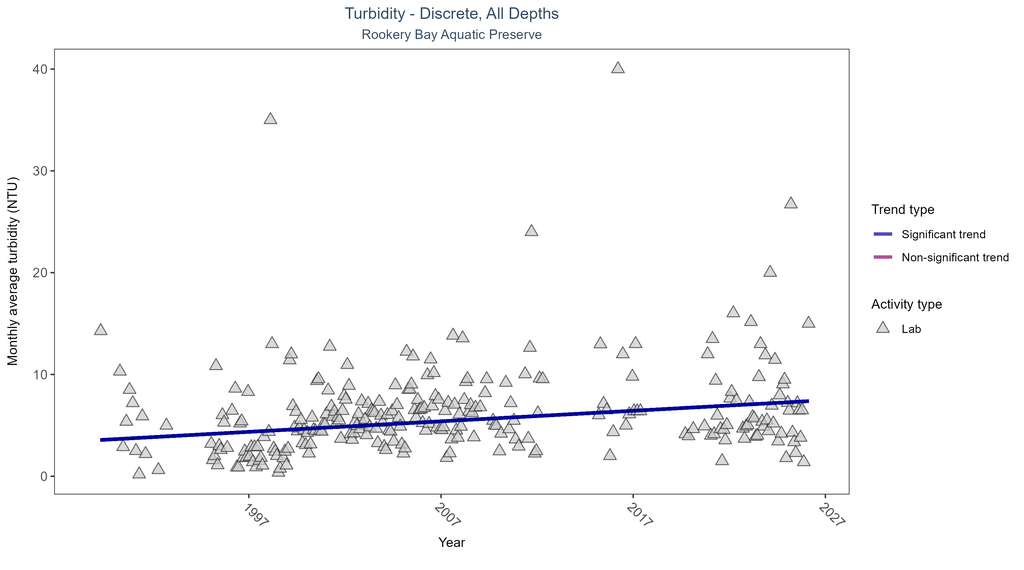

Scatter plot of monthly average turbidity over time. If the time series included ten or more years of discrete observations, a significant (blue) or non-significant (magenta) trend line is also shown. Only turbidity values measured in the laboratory (triangles) are included in the plot.

Table:

Monthly average turbidity increased by 0.1 NTU per year, indicating a decrease in water clarity.

| Activity Type | Statistical Trend | Sample Count | Years with Data | Period of Record | Median Result Value | Tau | Sen Intercept | Sen Slope | P |
| --- | --- | --- | --- | --- | --- | --- | --- | --- | --- |
| Lab | Increasing trend | 1892 | 33 | 1989 - 2026 | 4.9925 | 0.21521 | 3.5342 | 0.10353 | 0 |

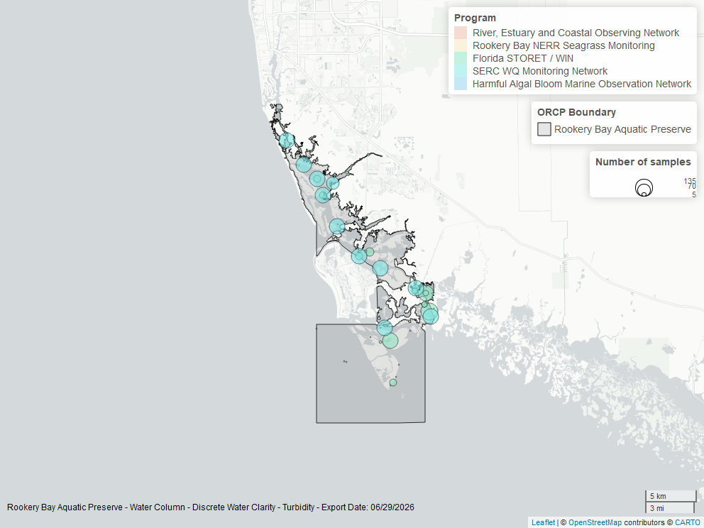

Map showing location of discrete water quality sampling locations within the boundaries of *Rookery Bay Aquatic Preserve*. The bubble size on the maps above reflect the amount of data available at each sampling site.

### Total Suspended Solids - Discrete

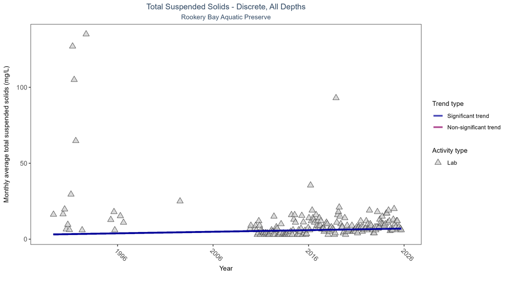

Scatter plot of monthly average total suspended solids (TSS) over time. If the time series included ten or more years of discrete observations, a significant (blue) or non-significant (magenta) trend line is also shown. Only TSS values obtained from laboratory analyses (triangles) are included in the plot.

Table:

Monthly average total suspended solids increased by 0.1 mg/L per year, indicating a decrease in water clarity.

| Activity Type | Statistical Trend | Sample Count | Years with Data | Period of Record | Median Result Value | Tau | Sen Intercept | Sen Slope | P |
| --- | --- | --- | --- | --- | --- | --- | --- | --- | --- |
| Lab | Increasing trend | 265 | 24 | 1989 - 2025 | 8 | 0.12857 | 3.1125 | 0.10455 | 0.0345 |

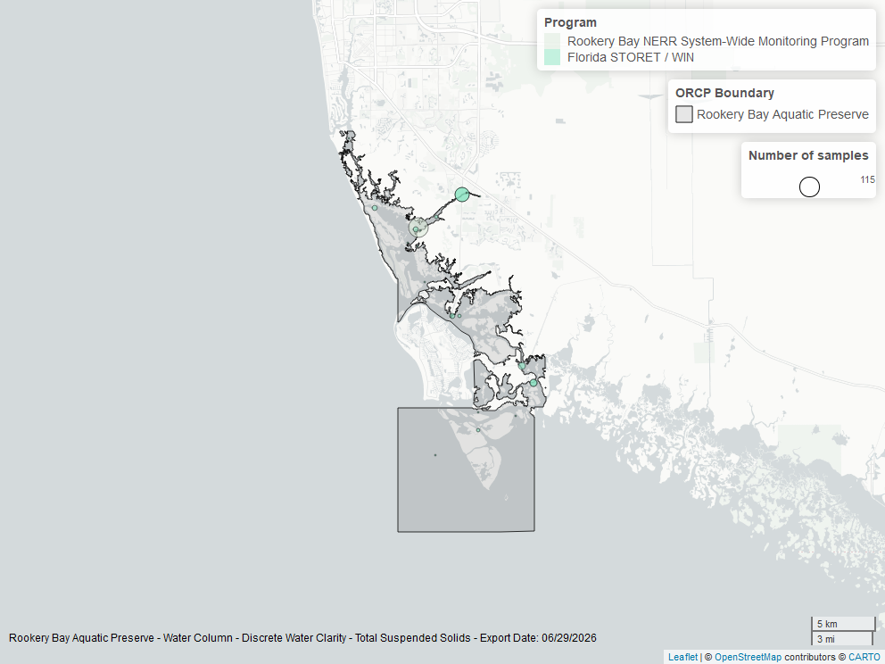

Map showing location of discrete water quality sampling locations within the boundaries of *Rookery Bay Aquatic Preserve*. The bubble size on the maps above reflect the amount of data available at each sampling site.